# Les éléments de la satisfaction liée à l’expérience de l’hôtellerie en Polynésie française

SB

01/11/2021

# Un corpus d’avis client de l’hôtellerie en Polynésie issu de Trip Advisor

[figure not shown]

```r
# df<-read_rds("Polynesie_tot.rds")
#
#
# df2<-df%>%mutate(pension=ifelse(str_detect(Hotel,"[p|P]ension|[r|R]anch|[b|B]unga*|[f|F]are|[c|C]halet|[a|A]uberge|[c|C]ottage|[g|G]esthouse|[v|V]illa|[c|C]amping|[l|L]odge|[d|D]ortoir|[c|C]hambre*")==T, 1,0))
#
# df2<-df2%>%
#   mutate(across(c(categorie, prix_classe,Taille_hotel),~coalesce(.x,replace_na("inconnue"))))%>%
#   filter(pension==0, categorie!="Hôtel famillial", prix_classe!="<10 000", Taille_hotel!=" 1-5 chambres",Note!=-1)
#
#
#
# df2%>%group_by(Hotel)%>%summarise(nb_com=n())%>%ggplot(aes(nb_com))+geom_bar(fill="darkred")+labs(x="Nombre de commentaires", y = "Nombre d'hôtels", title = "Distribution des commentaires")+coord_flip()
#
#
# df2<-df2 %>%
#   mutate(NPS=ifelse(Note<=4, "Détracteurs",
#                     ifelse(Note==5 ,"Promoteurs", "Passifs")))

df2<-read_rds("polynesie_hotel.rds")


hotel<-df2%>%group_by(Hotel)%>%summarise(nb_com=n())%>%mutate(Hotel=as.factor(Hotel))%>%arrange(desc(nb_com))

ggplot(hotel)+
  geom_col(aes(x=fct_reorder(Hotel,nb_com), y=nb_com), fill="darkred")+
  labs(x=NULL, y= "nb commentaires", title="Distribution des commentaires", subtitle = "n hôtels = 52, n commentaires = 24 031", caption = "data Trip Advisor entre 2001 et 2020")+
  coord_flip()
```

[figure not shown]

```r
year<-df2%>%mutate(année=as.factor(year(Date)))%>%group_by(année)%>%summarise(nb_com=n())

ggplot(year)+
  geom_col(aes(x=année, y=nb_com), fill="yellow3")+
  labs(x=NULL, y= "nb commentaires", title="Distribution des commentaires", subtitle = "n hôtels = 52, n commentaires = 24 031", caption = "data Trip Advisor entre 2001 et 2020")+
  coord_flip()
```

## Distribution des notes

Beaucoup d’hôtels avec peu de commentaires. Des notes exceptionnelles.

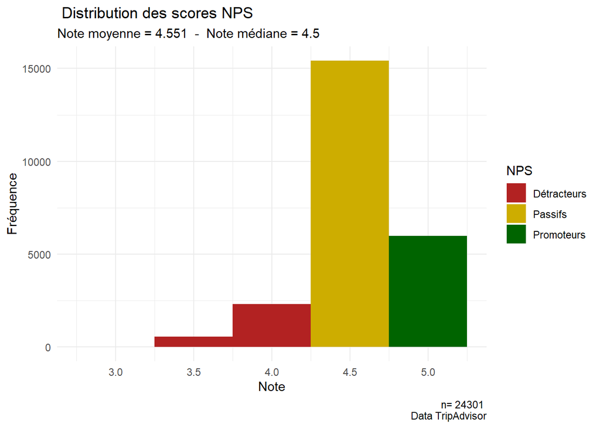

```r
ggplot(df2, aes(x=Note))+
  geom_histogram(binwidth = 0.5,aes(fill=NPS))+
  labs( title= " Distribution des scores NPS",
        subtitle = paste("Note moyenne =",round(mean(df2$Note),3)," -  Note médiane =",round(median(df2$Note),3)),
        caption = paste("n=",nrow(df2),"\nData TripAdvisor"),
        y = "Fréquence")+
  scale_fill_manual(values=col)
```

## Description des commentaires

On reconstitue le corpus avec les noms communs, les noms propres, les adjectifs et les verbes.

```r
# cnlp_init_udpipe(model_name = "french")
# annotate<-cnlp_annotate(df2, text_name = "Commetaire",doc_name = "ID", verbose = 1000)
#
# obj<-annotate$token
#
#
# obj<-read_rds("annotationPOS_hotel.rds")
#
# obj<-obj%>%mutate(nbcar=nchar(lemma))
#
#
# text2<-obj%>%filter(upos %in% c("ADJ","VERB","NOUN","PROPN"),nbcar>2)
#
# summary(text2$nbcar)
#
# text2<-text2%>%group_by(doc_id)%>%summarise(text=paste(lemma , collapse = " "))
#
# df2<-inner_join(df2,text2, by=c("ID"="doc_id"))
```

On crée le corpus, on ajuste les tokens avec les collocations.

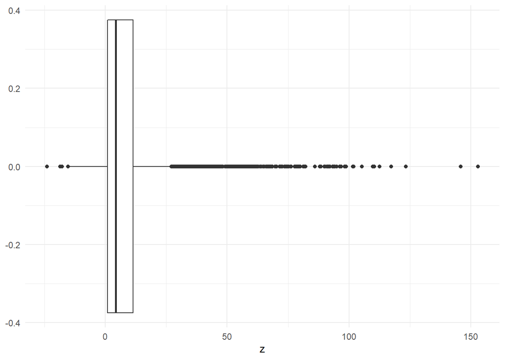

```r
# 1 définir le corpus

corpus<-corpus(df2,text_field ="text")

# 2 tokeniser le corpus

tok<-tokens(corpus, remove_punct = TRUE, remove_numbers = TRUE, remove_symbols = TRUE, remove_url = TRUE, remove_separators = TRUE)%>%
  tokens_remove(stopwords("fr"))

#Colloc des noms propres
toks3 <- tokens_select(tok, pattern = "^([A-Z][a-z\\-]{2,})", valuetype = "regex",
                       case_insensitive = FALSE, padding = TRUE)
tstat <- textstat_collocations(toks3, size = 2:3, tolower = FALSE)

tok<-tokens_compound(tok, pattern = tstat[tstat$z>8])


#Colloc du reste
toks4 <- tokens_select(tok, pattern = "^([a-z][a-z\\-]{2,})", valuetype = "regex",
                       case_insensitive = FALSE, padding = TRUE)

colloc<-textstat_collocations(toks4, min_count = 10, size=2:3, tolower = FALSE)
ggplot(colloc, aes(z))+geom_boxplot()
```

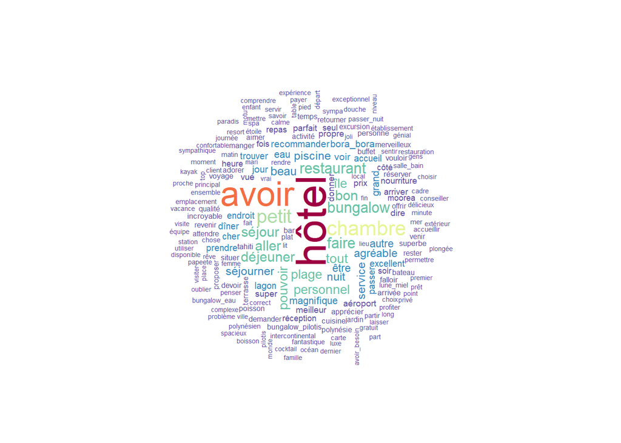

```r
tok<-tokens_compound(tok, pattern = colloc[colloc$z>25])


# 3 construire le dfm


dfm<-dfm(tok)
textplot_wordcloud(dfm,max_words = 200, color = rev(RColorBrewer::brewer.pal(10, "Spectral")))
```

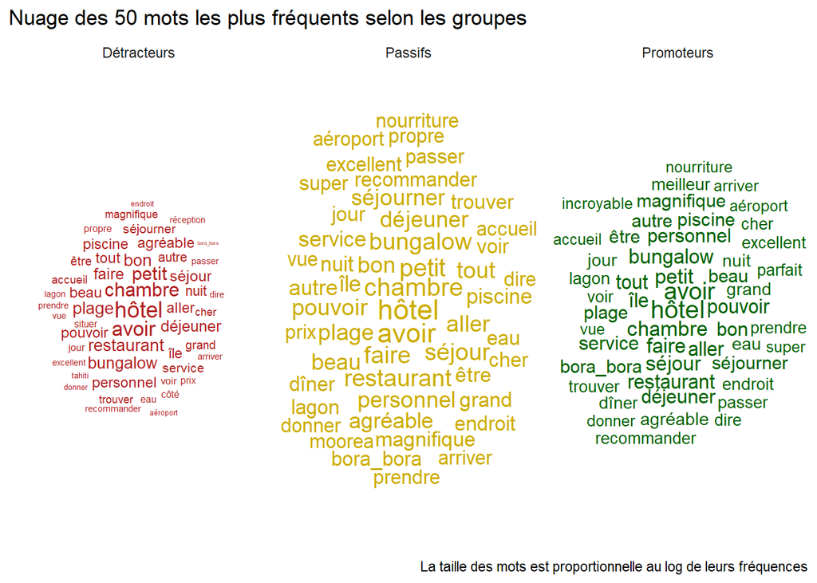

```r
#On construit un dfm groupé
dfm2 <-tok %>%
    tokens_group(groups = NPS) %>%
  dfm()

# 4 afficher le wordcloud

stat<- dfm2 %>%
  textstat_frequency(n = 50,  groups = NPS)

g_b<-ggplot(stat, aes(label = feature)) +
  geom_text_wordcloud(aes(size=log(frequency), color=group)) +
  theme_minimal()+
  facet_wrap(vars(group))+
  scale_color_manual(values=col)+
  labs(title="Nuage des 50 mots les plus fréquents selon les groupes",
       caption = "La taille des mots est proportionnelle au log de leurs fréquences")
g_b
```

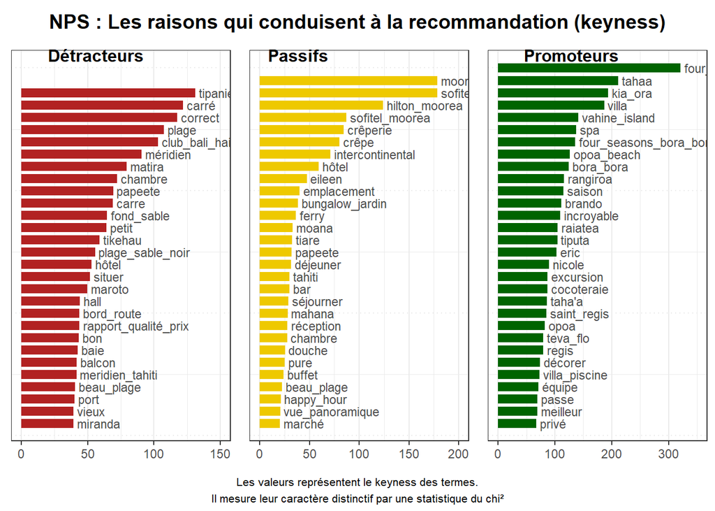

```r
#keyness
# Calculate keyness and determine "Promoteurs" as target group againts all other categories
result_keyness <- textstat_keyness(dfm2, target = "Promoteurs")

# Plot estimated word keyness
g1<-textplot_keyness(result_keyness,   n = 30L, labelsize = 3,   show_legend = FALSE,
                     show_reference = FALSE,   color = c("Darkgreen", "gray"))+
  xlim(0,350) +
  labs(x=NULL)


result_keyness <- textstat_keyness(dfm2, target = "Détracteurs" )
g2<-textplot_keyness(result_keyness,   n = 30L, labelsize = 3,   show_legend = FALSE,
                     show_reference = FALSE,   color = c("firebrick", "gray"))+
  xlim(0,150)+
  labs(x=NULL)


result_keyness <- textstat_keyness(dfm2, target = "Passifs")
g3<-textplot_keyness(result_keyness,   n = 30L, labelsize = 3,   show_legend = FALSE,   show_reference = FALSE,    color = c("gold2", "gray"))+xlim(0,200)+ labs(x=NULL)



p<- plot_grid(g2, g3 ,g1,  labels = c('Détracteurs', 'Passifs', 'Promoteurs'), label_size = 12, ncol=3)
title <- ggdraw() + draw_label("NPS : Les raisons qui conduisent à la recommandation (keyness)", fontface='bold')
note <- ggdraw()+ draw_text("Les valeurs représentent le keyness des termes.\nIl mesure leur caractère distinctif par une statistique du chi²", size=8,x = 0.5, y = 0.5)

plot_grid(title, p,note, ncol=1, rel_heights=c(0.1, 1)) # rel_heights values control title margins
```

# Modèle de *topics* supervisé : seededLDA

## Le dictionnaire

On crée un dictionnaire des attributs d’un séjour en Polynésie. On s’attend à trouver deux types d’information dans les commentaires : ce qui est lié à la Polynésie et à son cadre exceptionnel, et ce qui est lié à l’hôtel et à l’expérience vécue par les clients. On cherche à rester factuel, sans a priori sur les qualificatifs de ces attributs.

```r
dict <- quanteda::dictionary(list(Paysage = c("motu", "océan","lagon","plage", "récif", "corail", "coraux"),
                     Activité = c("vélo","kayak","nage","excursion","golf","baleine","dauphin","plongée","requin","tortue","snorkeling"),
                         Service = c("restaurant", "petit_déjeuner", "cuisine","bar","piscine","massage","thalasso"),
                         Accueil = c("accueil","personnel","conseil","équipe","réservation","réception","annulation"),
                         Chambre =c("chambre","salle_bain","lit","toilettes"),
                         Prix=c("prix","qualité_prix")))

dict
```

```
## Dictionary object with 6 key entries.
## - [Paysage]:
##   - motu, océan, lagon, plage, récif, corail, coraux
## - [Activité]:
##   - vélo, kayak, nage, excursion, golf, baleine, dauphin, plongée, requin, tortue, snorkeling
## - [Service]:
##   - restaurant, petit_déjeuner, cuisine, bar, piscine, massage, thalasso
## - [Accueil]:
##   - accueil, personnel, conseil, équipe, réservation, réception, annulation
## - [Chambre]:
##   - chambre, salle_bain, lit, toilettes
## - [Prix]:
##   - prix, qualité_prix
```

```r
head(dfm_lookup(dfm, dict))
```

```
## Document-feature matrix of: 6 documents, 6 features (75.00% sparse) and 25 docvars.
##        features
## docs    Paysage Activité Service Accueil Chambre Prix
##   text1       0        0       0       2       0    0
##   text2       0        0       0       1       1    0
##   text3       0        0       1       1       0    0
##   text4       0        0       0       0       0    0
##   text5       3        0       0       0       0    0
##   text6       2        1       0       2       0    0
```

## Le modèle : seedLDA

On ajuste d’abord le vocabulaire, puis on lance directement le modèle. On décrit ensuite les *topics*.

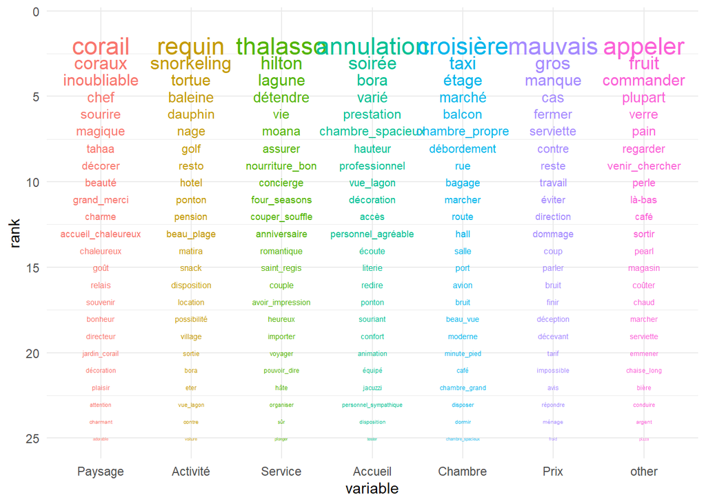

```r
news_dfm <- dfm %>%
  dfm_trim(min_docfreq = 0.0001, max_termfreq = 0.995, docfreq_type = "prop",termfreq_type = "quantile")


set.seed(1234)
slda <- textmodel_seededlda(news_dfm, dict, residual = TRUE)



lda_res<-as.data.frame(seededlda::terms(slda, 25))%>%
  mutate(rank=as.numeric(row.names(.)))%>%
  melt(id.vars=c("rank"))

ggplot(lda_res, aes(x=variable, y= rank, group =  value , label = value)) +
  scale_y_reverse() +
  geom_text(aes(color=variable,size=8/log(rank)))+
  theme_minimal()+
  scale_color_hue()+
  guides(color="none",size="none")
```

## Analyse factorielle

On récupère les topics dominants pour chaque commentaire, et on croise cela avec les profils de recommandation.

```r
news_dfm$seededtopic <- seededlda::topics(slda)

summary(news_dfm$seededtopic)
```

```
##  Paysage Activité  Service  Accueil  Chambre     Prix    other     NA's
##     3684     3454     4227     3695     3528     3072     2636        5
```

```r
ca<- table(news_dfm$seededtopic, news_dfm$NPS)
prop.table(ca, 2)
```

```
##
##            Détracteurs    Passifs Promoteurs
##   Paysage   0.10282954 0.13366658 0.22138805
##   Activité  0.20945480 0.13827577 0.11961962
##   Service   0.05831608 0.16852766 0.24391058
##   Accueil   0.15044859 0.15768632 0.13847181
##   Chambre   0.21325052 0.15775123 0.08008008
##   Prix      0.18426501 0.12730460 0.09626293
##   other     0.08143547 0.11678785 0.10026693
```

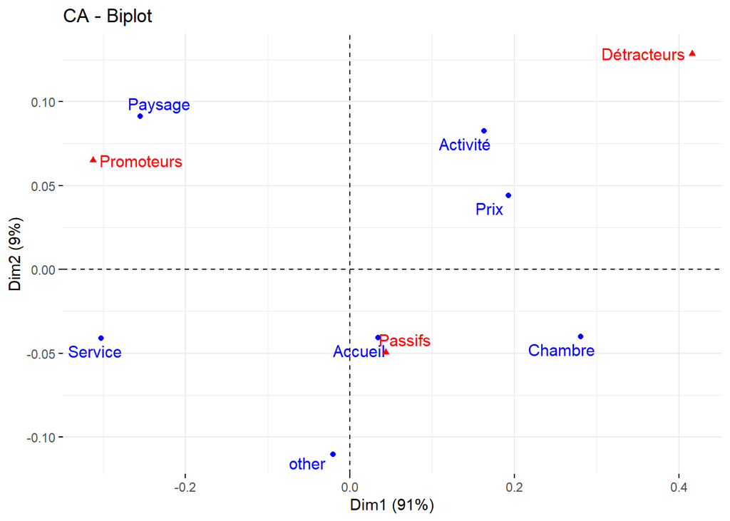

```r
res.ca <- CA (ca, graph = FALSE)
fviz_ca_biplot (res.ca, repel = TRUE)
```

## Modèle GAM

Pour finir, on cherche à expliquer la note en fonction des topics abordés dans les commentaires, en utilisant des modèles GAM :

```r
theta2<-slda$theta
topic2<-cbind(df2,theta2)

mod1 <- gam(Note ~ s(Paysage) + s(Activité)+ s(Service)+ s(Accueil)+ s(Chambre)+ s(Prix),
data = topic2, family = gaussian)

summary(mod1)
```

```
##
## Call: gam(formula = Note ~ s(Paysage) + s(Activité) + s(Service) +
##     s(Accueil) + s(Chambre) + s(Prix), family = gaussian, data = topic2)
## Deviance Residuals:
##      Min       1Q   Median       3Q      Max
## -1.55186 -0.11912 -0.01859  0.09889  0.61928
##
## (Dispersion Parameter for gaussian family taken to be 0.1011)
##
##     Null Deviance: 2624.619 on 24300 degrees of freedom
## Residual Deviance: 2454.202 on 24276 degrees of freedom
## AIC: 13299.96
##
## Number of Local Scoring Iterations: NA
##
## Anova for Parametric Effects
##                Df  Sum Sq Mean Sq F value    Pr(>F)
## s(Paysage)      1   45.76  45.756 452.601 < 2.2e-16 ***
## s(Activité)     1    7.56   7.561  74.787 < 2.2e-16 ***
## s(Service)      1   80.05  80.047 791.792 < 2.2e-16 ***
## s(Accueil)      1    7.41   7.411  73.308 < 2.2e-16 ***
## s(Chambre)      1   15.45  15.446 152.787 < 2.2e-16 ***
## s(Prix)         1    6.76   6.764  66.910  2.98e-16 ***
## Residuals   24276 2454.20   0.101
## ---
## Signif. codes:  0 '***' 0.001 '**' 0.01 '*' 0.05 '.' 0.1 ' ' 1
##
## Anova for Nonparametric Effects
##             Npar Df  Npar F     Pr(F)
## (Intercept)
## s(Paysage)        3  3.8002  0.009755 **
## s(Activité)       3  0.4069  0.748061
## s(Service)        3 10.3591 8.262e-07 ***
## s(Accueil)        3  0.8779  0.451648
## s(Chambre)        3 10.5068 6.677e-07 ***
## s(Prix)           3  4.5063  0.003646 **
## ---
## Signif. codes:  0 '***' 0.001 '**' 0.01 '*' 0.05 '.' 0.1 ' ' 1
```

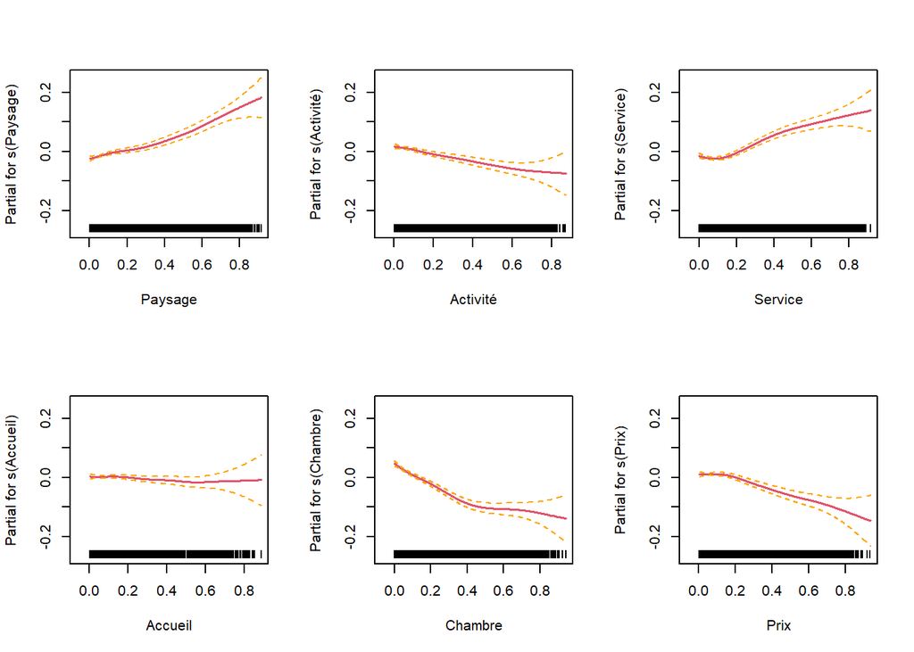

```r
par(mfrow = c(2, 3))

termplot(mod1,rug = TRUE, se = TRUE,  terms = c("s(Paysage)", "s(Activité)", "s(Service)", "s(Accueil)", "s(Chambre)", "s(Prix)"))
```